# Data Analysis of Top Tennis Players' Career Ace Performance

## ITCS-3162: Introduction to Data Mining, Project 1

**Andrew Morgan**

Among many popular team sports, tennis has differentiated itself as perhaps the most played and one of the most watched individual sports. All your errors are your own, and how your individual performance changes over time is the (pretty much) only relevant statistic. At the top of the game, the margin for error in individual performance becomes razor-thin; what might match-by-match performance data tell us about how Novak Djokovic or Jannik Sinner subtly adjust and improve their game to try and beat those margins? What might it tell us about their approach to the game in general? The goal of this project is to **identify trends in top tennis players' ace performance data and make data-driven inferences about how they changed their games over time** (or failed to do so), and **infer their general playing style**. I'm also interested in **comparing the evolutions of various top tennis players' acing games**.

I use Jeff Sackman's publicly available ATP match dataset: https://github.com/JeffSackmann/tennis_atp. I found this data from this list of datasets provided on our Canvas page: https://github.com/awesomedata/awesome-public-datasets

Inspired by wanting to expand on this video on Djokovic's serving performance evolution from ESPN: https://www.youtube.com/watch?v=s200n5ejiFc

## Data Preparation

Let's start by initializing the dataset of every ATP player.

```python
# !pip install pandas
import pandas as pd

# disabling annoying warnings first
# used google search ai to learn how to disable specific warnings with simplefilter(), for instance below with DTypeWarning
import warnings
warnings.simplefilter(action="ignore", category=pd.errors.DtypeWarning)  # ignore the annoying dtypewarning
warnings.simplefilter(action="ignore", category=pd.errors.SettingWithCopyWarning)  # ignore the annoying SettingWithCopyWarning

players = pd.read_csv("atp_players.csv")
players.shape
```

```
(65989, 8)
```

```python
players.head()
```

|  | player_id | name_first | name_last | hand | dob | ioc | height | wikidata_id |
| --- | --- | --- | --- | --- | --- | --- | --- | --- |
| 0 | 100001 | Gardnar | Mulloy | R | 19131122.0 | USA | 185.0 | Q54544 |
| 1 | 100002 | Pancho | Segura | R | 19210620.0 | ECU | 168.0 | Q54581 |
| 2 | 100003 | Frank | Sedgman | R | 19271002.0 | AUS | 180.0 | Q962049 |
| 3 | 100004 | Giuseppe | Merlo | R | 19271011.0 | ITA | NaN | Q1258752 |
| 4 | 100005 | Richard | Gonzalez | R | 19280509.0 | USA | 188.0 | Q53554 |

Before choosing the players we would like to analyze closely, we can look briefly at some interesting, relevant facts about all ATP players. Like in basketball and most sports, height is a major advantage, particularly when it comes to acing opponents and generally serving well. Who are the tallest ATP players (one of whom I'll take a closer look at later on)?

```python
players["height"] = players["height"].fillna(players["height"].mean())
players.nlargest(10, "height", keep="first")
```

|  | player_id | name_first | name_last | hand | dob | ioc | height | wikidata_id |
| --- | --- | --- | --- | --- | --- | --- | --- | --- |
| 24171 | 124187 | Reilly | Opelka | R | 19970828.0 | USA | 211.0 | Q20655502 |
| 3332 | 103333 | Ivo | Karlovic | R | 19790228.0 | CRO | 208.0 | Q295483 |
| 4543 | 104545 | John | Isner | R | 19850426.0 | USA | 208.0 | Q53566 |
| 60018 | 207732 | Miguel | Damas | R | 19991221.0 | ESP | 208.0 | NaN |
| 708 | 100709 | Greg | Neuhart | R | 19601202.0 | USA | 206.0 | NaN |
| 52651 | 200365 | Christian | Seraphim | R | 19950525.0 | GER | 206.0 | Q25016211 |
| 54412 | 202126 | Jaimee Floyd | Angele | R | 20000327.0 | FRA | 206.0 | NaN |
| 64051 | 211767 | James | Watt | R | 20000609.0 | NZL | 206.0 | NaN |
| 989 | 100990 | Milan | Srejber | R | 19631230.0 | CZE | 203.0 | Q1286130 |
| 1867 | 101868 | Dick | Norman | L | 19710301.0 | BEL | 203.0 | Q378208 |

Our tallest is Reilly Opelka at 6'11. The shortest?

```python
players.nsmallest(10, "height", keep="first")
```

|  | player_id | name_first | name_last | hand | dob | ioc | height | wikidata_id |
| --- | --- | --- | --- | --- | --- | --- | --- | --- |
| 6395 | 106410 | Jorge Brian | Panta Herreros | R | 19950722.0 | PER | 3.0 | Q22007316 |
| 64477 | 212193 | Alexander | Stater | R | 19990421.0 | USA | 13.0 | NaN |
| 27034 | 127050 | Kooros | Ghasemi | R | 19940829.0 | CAN | 15.0 | NaN |
| 34071 | 134087 | Johannes | Ingildsen | R | 19970701.0 | DEN | 15.0 | Q108458188 |
| 60062 | 207776 | William | Grant | R | 20010213.0 | USA | 15.0 | NaN |
| 33086 | 133102 | Radoslav | Shandarov | R | 19960711.0 | BUL | 71.0 | Q47890285 |
| 62193 | 209907 | Viacheslav | Bielinskyi | R | 20031202.0 | UKR | 71.0 | NaN |
| 63806 | 211522 | Andrew | Rogers | R | 19981218.0 | USA | 132.0 | NaN |
| 5647 | 105661 | Ilija | Vucic | R | 19901027.0 | SRB | 145.0 | NaN |
| 60273 | 207987 | Ryuki | Matsuda | R | 19991228.0 | JPN | 157.0 | NaN |

3 centimeters? In fact, this is Jorge Brian Panta Herreros' official listed height per the ATP: https://www.atptour.com/en/players/jorge-panta/pg56/overview? Still, let's fill the obviously wrong values with the mean value.

```python
players["height"] = players["height"].apply(lambda val: players["height"].mean() if val < 100.0 else val)
players.nsmallest(10, "height", keep="first")
```

|  | player_id | name_first | name_last | hand | dob | ioc | height | wikidata_id |
| --- | --- | --- | --- | --- | --- | --- | --- | --- |
| 63806 | 211522 | Andrew | Rogers | R | 19981218.0 | USA | 132.0 | NaN |
| 5647 | 105661 | Ilija | Vucic | R | 19901027.0 | SRB | 145.0 | NaN |
| 60273 | 207987 | Ryuki | Matsuda | R | 19991228.0 | JPN | 157.0 | NaN |
| 65259 | 212975 | Woohyuk | Chang | R | NaN | KOR | 157.0 | NaN |
| 619 | 100620 | Eduardo | Osta | L | 19590904.0 | ESP | 160.0 | Q5340720 |
| 1801 | 101802 | Ramayah | Ramachandran | R | 19700910.0 | MAS | 160.0 | Q55767560 |
| 58289 | 206003 | Chih Chi | Huang | R | 20001114.0 | CAN | 160.0 | NaN |
| 393 | 100394 | Angel | Gimenez | R | 19551010.0 | ESP | 163.0 | Q8076837 |
| 696 | 100697 | Choon Ho | Kim | R | 19600902.0 | KOR | 163.0 | Q55760972 |
| 54408 | 202122 | Yuta | Shimizu | L | 19990609.0 | JPN | 163.0 | Q105776850 |

Now let's select some players. Let's take a look at the career and performance evolution of who is commonly called the GOAT, Roger Federer. Our goal here is to understand through match data how he adjusted and tweaked his game over the hundreds of matches he's played to rise to the top and stay there for as long as he has. I'll look up his player_id and take a look at his ranking over time first.

```python
# used google search ai here to help with how to do complex conditional dataframe filtering like the below
federer_index = players.index[(players["name_first"] == "Roger") & (players["name_last"] == "Federer")]
players.loc[federer_index]
```

|  | player_id | name_first | name_last | hand | dob | ioc | height | wikidata_id |
| --- | --- | --- | --- | --- | --- | --- | --- | --- |
| 3818 | 103819 | Roger | Federer | R | 19810808.0 | SUI | 185.0 | Q1426 |

Looking up his ranking over time by loading the ATP rankings datasets.

```python
federer_id = players.at[federer_index[0], "player_id"]

rankings_90s = pd.read_csv("atp_rankings_90s.csv")
rankings_00s = pd.read_csv("atp_rankings_00s.csv")
rankings_10s = pd.read_csv("atp_rankings_10s.csv")
rankings_20s = pd.read_csv("atp_rankings_20s.csv")
rankings = pd.concat([rankings_90s, rankings_00s, rankings_10s, rankings_20s])
rankings.columns
```

```
Index(['ranking_date', 'rank', 'player', 'points'], dtype='object')
```

```python
rankings = rankings[rankings["player"] == federer_id]  # filter out Federer's per-week rankings
rankings.shape
```

```
(1203, 4)
```

Now that we have Federer's rankings from when he first entered the ATP rankings to his retirement in the 2020s, we can plot his rankings over his 1203 weeks.

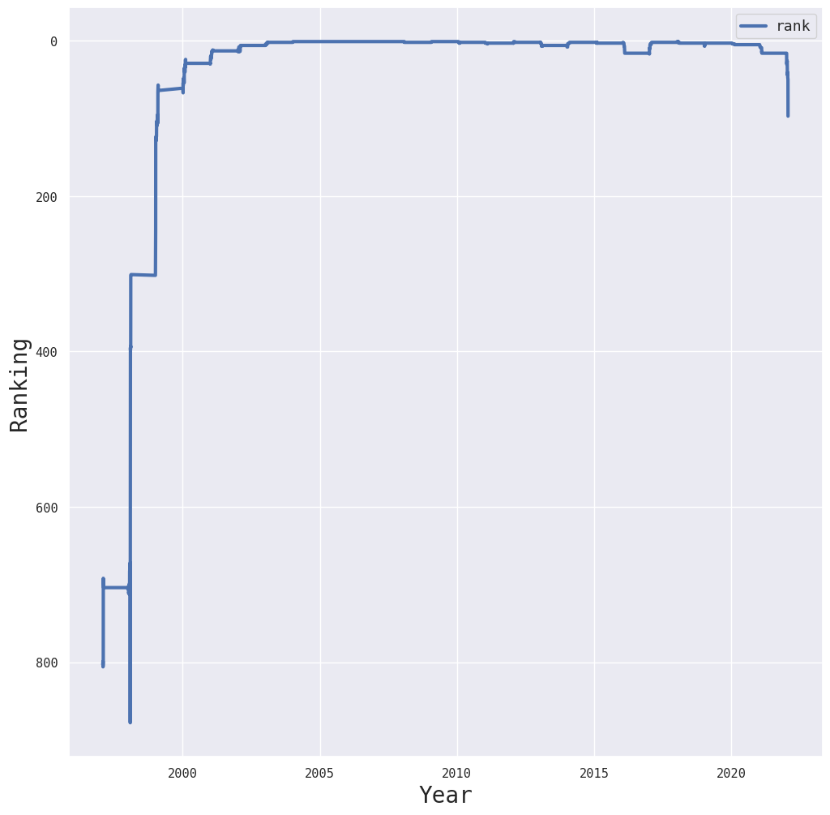

```python
import seaborn as sns
from matplotlib import pyplot as plt
import matplotlib.ticker as ticker
from matplotlib.ticker import MultipleLocator

# wrapper method used throughout the notebook to easily and modularly plot player data
def plot_data(df, xlabel, ylabel, invert, confidence_interval=True):
    # setting up the plot
    sns.set(font="monospace", rc={"figure.figsize":(12,12)})
    plot = None
    if confidence_interval:
        plot = sns.lineplot(data=df, linewidth=3)
    else:
        plot = sns.lineplot(data=df, linewidth=3, errorbar=None)

    # used google search ai to find and understand how to set the axis label and invert axes in matplotlib/seaborn
    plot.set_xlabel(xlabel, fontsize=20)
    plot.set_ylabel(ylabel, fontsize=20)

    plt.setp(plt.gca().get_legend().get_texts(), fontsize=13)

    if invert:
        plot.invert_yaxis()

    # rounding the x ticks
    plt.gca().xaxis.set_major_formatter(ticker.FuncFormatter(lambda tick, pos: "{:.0f}".format(tick)[:4]))

    plt.show()

rankings = rankings[["ranking_date", "rank"]]

# replacing the index labels with the rank date to easily plot it with sns.lineplot(data=df ...)
# rather than sns.lineplot(x=..., y=..., ...)
# used google search ai to find methods of setting the index labels to a column's data and decided to use
# setting the index directly with a list of the column
rankings.index = rankings["ranking_date"].to_numpy().tolist()
rankings_plot = rankings.drop("ranking_date", axis=1)

plot_data(rankings_plot, "Year", "Ranking", invert=True)
```

Once again, but with rankings before 2000 excluded:

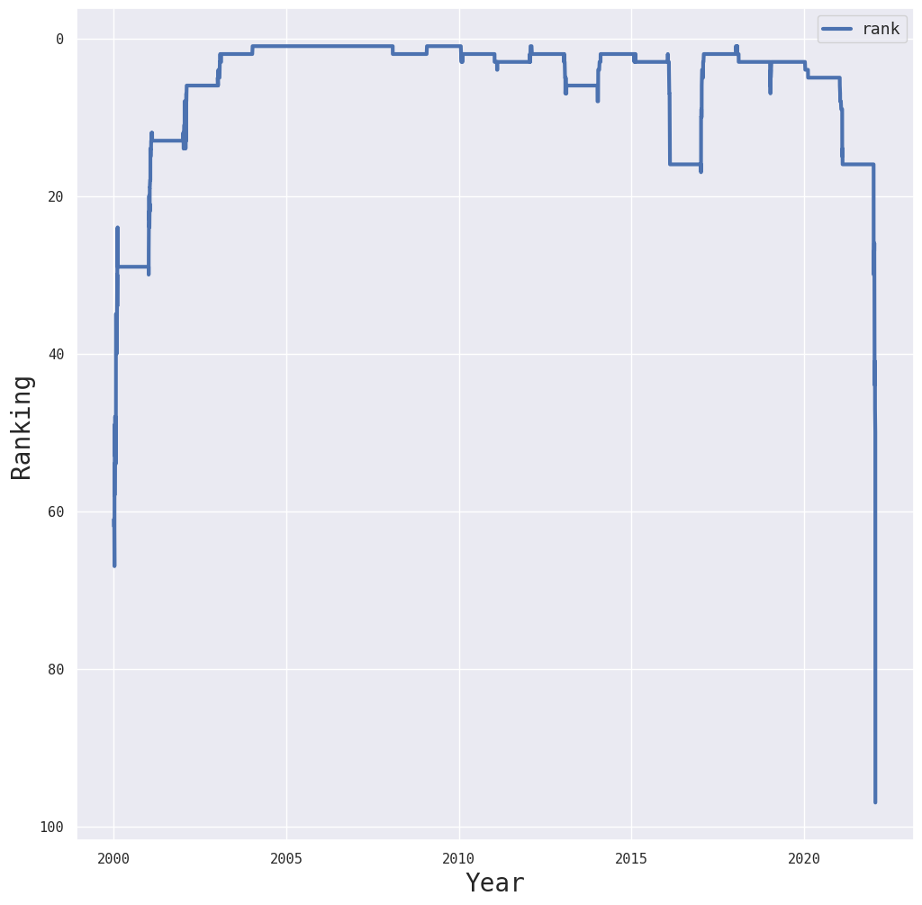

```python
rankings = rankings[rankings["ranking_date"] > 20000101]
rankings.index = rankings["ranking_date"].to_numpy().tolist()
rankings_plot = rankings.drop("ranking_date", axis=1)
plot_data(rankings_plot, "Year", "Ranking", invert=True)
```

Now let's plot Federer's rankings against some selected match performance features. The match data is organized by year, so I'll need to do some wrangling to get it into one dataframe.

```python
from glob import glob

matches_by_year = []
paths = glob(pathname="match_data/*.csv")
for path in paths:
    matches_by_year.append(pd.read_csv(path))
matches = pd.concat(matches_by_year)

# saving full match data for later use
full_matches = matches
```

Here are the match dataset features, of which I will use tourney_date, winner_id, loser_id, w_ace/l_ace, and w_svpt/l_svpt (the winner/losers's number of service points) to find players' ace rates.

```python
matches.columns
```

```
Index(['tourney_id', 'tourney_name', 'surface', 'draw_size', 'tourney_level',
       'tourney_date', 'match_num', 'winner_id', 'winner_seed', 'winner_entry',
       'winner_name', 'winner_hand', 'winner_ht', 'winner_ioc', 'winner_age',
       'loser_id', 'loser_seed', 'loser_entry', 'loser_name', 'loser_hand',
       'loser_ht', 'loser_ioc', 'loser_age', 'score', 'best_of', 'round',
       'minutes', 'w_ace', 'w_df', 'w_svpt', 'w_1stIn', 'w_1stWon', 'w_2ndWon',
       'w_SvGms', 'w_bpSaved', 'w_bpFaced', 'l_ace', 'l_df', 'l_svpt',
       'l_1stIn', 'l_1stWon', 'l_2ndWon', 'l_SvGms', 'l_bpSaved', 'l_bpFaced',
       'winner_rank', 'winner_rank_points', 'loser_rank', 'loser_rank_points'],
      dtype='object')
```

```python
matches.shape
```

```
(81831, 49)
```

```python
matches
```

|  | tourney_id | tourney_name | surface | draw_size | tourney_level | tourney_date | match_num | winner_id | winner_seed | winner_entry | ... | l_1stIn | l_1stWon | l_2ndWon | l_SvGms | l_bpSaved | l_bpFaced | winner_rank | winner_rank_points | loser_rank | loser_rank_points |
| --- | --- | --- | --- | --- | --- | --- | --- | --- | --- | --- | --- | --- | --- | --- | --- | --- | --- | --- | --- | --- | --- |
| 0 | 1998-339 | Adelaide | Hard | 32 | A | 19980105 | 1 | 102035 | 1.0 | NaN | ... | 29.0 | 18.0 | 11.0 | 9.0 | 2.0 | 5.0 | 4.0 | 2949.0 | 74.0 | 649.0 |
| 1 | 1998-339 | Adelaide | Hard | 32 | A | 19980105 | 2 | 101727 | NaN | NaN | ... | 32.0 | 19.0 | 11.0 | 8.0 | 9.0 | 13.0 | 79.0 | 617.0 | 87.0 | 537.0 |
| 2 | 1998-339 | Adelaide | Hard | 32 | A | 19980105 | 3 | 102765 | NaN | Q | ... | 38.0 | 18.0 | 7.0 | 9.0 | 5.0 | 12.0 | 93.0 | 521.0 | 71.0 | 665.0 |
| 3 | 1998-339 | Adelaide | Hard | 32 | A | 19980105 | 4 | 102563 | 7.0 | NaN | ... | 37.0 | 21.0 | 10.0 | 11.0 | 1.0 | 6.0 | 39.0 | 959.0 | 76.0 | 633.0 |
| 4 | 1998-339 | Adelaide | Hard | 32 | A | 19980105 | 5 | 102796 | 4.0 | NaN | ... | 57.0 | 33.0 | 20.0 | 13.0 | 12.0 | 17.0 | 22.0 | 1450.0 | 65.0 | 708.0 |
| ... | ... | ... | ... | ... | ... | ... | ... | ... | ... | ... | ... | ... | ... | ... | ... | ... | ... | ... | ... | ... | ... |
| 3071 | 2024-M-DC-2024-WG2-PO-URU-MDA-01 | Davis Cup WG2 PO: URU vs MDA | Clay | 4 | D | 20240203 | 5 | 212051 | NaN | NaN | ... | 30.0 | 17.0 | 7.0 | 6.0 | 8.0 | 14.0 | 1109.0 | 8.0 | 740.0 | 34.0 |
| 3072 | 2024-M-DC-2024-WG2-PO-VIE-RSA-01 | Davis Cup WG2 PO: VIE vs RSA | Hard | 4 | D | 20240202 | 1 | 122533 | NaN | NaN | ... | 41.0 | 25.0 | 6.0 | 9.0 | 1.0 | 4.0 | 554.0 | 67.0 | 748.0 | 32.0 |
| 3073 | 2024-M-DC-2024-WG2-PO-VIE-RSA-01 | Davis Cup WG2 PO: VIE vs RSA | Hard | 4 | D | 20240202 | 2 | 144748 | NaN | NaN | ... | 51.0 | 25.0 | 7.0 | 11.0 | 5.0 | 12.0 | 416.0 | 109.0 | NaN | NaN |
| 3074 | 2024-M-DC-2024-WG2-PO-VIE-RSA-01 | Davis Cup WG2 PO: VIE vs RSA | Hard | 4 | D | 20240202 | 4 | 122533 | NaN | NaN | ... | 51.0 | 32.0 | 17.0 | 14.0 | 5.0 | 9.0 | 554.0 | 67.0 | 416.0 | 109.0 |
| 3075 | 2024-M-DC-2024-WG2-PO-VIE-RSA-01 | Davis Cup WG2 PO: VIE vs RSA | Hard | 4 | D | 20240202 | 5 | 202475 | NaN | NaN | ... | 53.0 | 25.0 | 8.0 | 8.0 | 9.0 | 14.0 | 748.0 | 32.0 | NaN | NaN |

81831 rows × 49 columns

Let's get all of Federer's matches:

```python
matches = matches[(matches["winner_id"] == federer_id) | (matches["loser_id"] == federer_id)]
matches.shape
```

```
(1545, 49)
```

Let's look first at the number of aces made by Federer across all his matches, which takes a little bit of doing because aces are distributed in l_ace (loser ace count) and w_ace (winner ace count) columns. We'll save the svpt (serve points) column as well for later normalization of the raw ace data:

```python
import numpy as np

# get all the ace data from matches where federer lost and where he won, and combine it into one dataframe of all of federer's raw ace data
loser_aces = (matches[matches["loser_id"] == federer_id])[["tourney_date", "l_ace", "l_svpt"]]
winner_aces = (matches[matches["winner_id"] == federer_id])[["tourney_date", "w_ace", "w_svpt"]]
aces = pd.concat([loser_aces, winner_aces])
aces = aces.sort_values("tourney_date")
aces
```

|  | tourney_date | l_ace | l_svpt | w_ace | w_svpt |
| --- | --- | --- | --- | --- | --- |
| 2030 | 19980706 | 1.0 | 74.0 | NaN | NaN |
| 3095 | 19980928 | NaN | NaN | 8.0 | 73.0 |
| 3086 | 19980928 | NaN | NaN | 8.0 | 41.0 |
| 3100 | 19980928 | 3.0 | 67.0 | NaN | NaN |
| 3108 | 19981005 | 4.0 | 53.0 | NaN | NaN |
| ... | ... | ... | ... | ... | ... |
| 1675 | 20210628 | 5.0 | 93.0 | NaN | NaN |
| 1660 | 20210628 | NaN | NaN | 7.0 | 114.0 |
| 1600 | 20210628 | NaN | NaN | 16.0 | 112.0 |
| 1640 | 20210628 | NaN | NaN | 10.0 | 95.0 |
| 1670 | 20210628 | NaN | NaN | 4.0 | 78.0 |

1545 rows × 5 columns

```python
# since federer's ace data is still distributed across loser_aces and winner_aces, merge it into one "aces" row
aces["aces"] = np.where(aces["l_ace"].isna(), aces["w_ace"], aces["l_ace"])
aces["serve_points"] = np.where(aces["l_svpt"].isna(), aces["w_svpt"], aces["l_svpt"])
aces = aces[["tourney_date", "aces", "serve_points"]]
aces = aces.dropna()  # drop columns where either the serve points or ace count is null
aces
```

|  | tourney_date | aces | serve_points |
| --- | --- | --- | --- |
| 2030 | 19980706 | 1.0 | 74.0 |
| 3095 | 19980928 | 8.0 | 73.0 |
| 3086 | 19980928 | 8.0 | 41.0 |
| 3100 | 19980928 | 3.0 | 67.0 |
| 3108 | 19981005 | 4.0 | 53.0 |
| ... | ... | ... | ... |
| 1675 | 20210628 | 5.0 | 93.0 |
| 1660 | 20210628 | 7.0 | 114.0 |
| 1600 | 20210628 | 16.0 | 112.0 |
| 1640 | 20210628 | 10.0 | 95.0 |
| 1670 | 20210628 | 4.0 | 78.0 |

1458 rows × 3 columns

Let's normalize the number of aces per match by the number of service points to get ace rate percentage:

```python
aces["ace_rate"] = (aces["aces"] / aces["serve_points"]) * 100
aces
```

|  | tourney_date | aces | serve_points | ace_rate |
| --- | --- | --- | --- | --- |
| 2030 | 19980706 | 1.0 | 74.0 | 1.351351 |
| 3095 | 19980928 | 8.0 | 73.0 | 10.958904 |
| 3086 | 19980928 | 8.0 | 41.0 | 19.512195 |
| 3100 | 19980928 | 3.0 | 67.0 | 4.477612 |
| 3108 | 19981005 | 4.0 | 53.0 | 7.547170 |
| ... | ... | ... | ... | ... |
| 1675 | 20210628 | 5.0 | 93.0 | 5.376344 |
| 1660 | 20210628 | 7.0 | 114.0 | 6.140351 |
| 1600 | 20210628 | 16.0 | 112.0 | 14.285714 |
| 1640 | 20210628 | 10.0 | 95.0 | 10.526316 |
| 1670 | 20210628 | 4.0 | 78.0 | 5.128205 |

1458 rows × 4 columns

Finally, we have our target metric. Let's do some final data preparation:

```python
aces = aces[["tourney_date", "ace_rate"]]
aces["tourney_date"] = aces["tourney_date"].apply(lambda val: int(str(val)[:4]))  # only get the year
federer_aces = aces.rename(columns={"ace_rate": "federer"})  # we'll add other players later; denote federer's ace rate
federer_aces.index = federer_aces["tourney_date"].to_numpy().tolist()
federer_aces_plot = federer_aces.drop("tourney_date", axis=1)
```

## Visualization

Let's now visualize our prepared data. Below, the shadow is the confidence interval or the spread around the mean for that region/year of data.

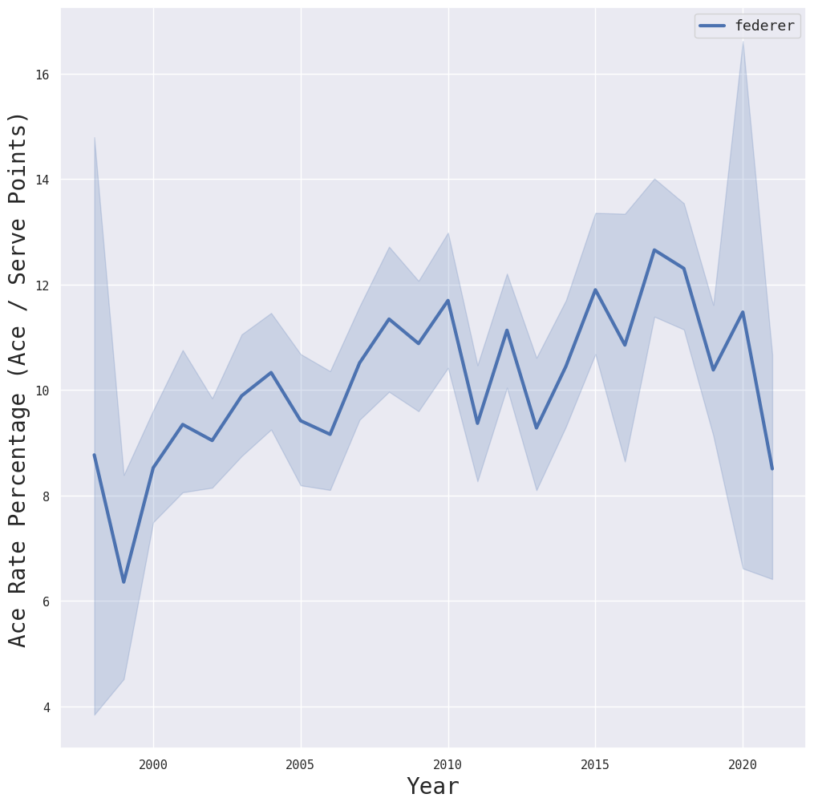

```python
plot_data(federer_aces_plot, xlabel="Year", ylabel="Ace Rate Percentage (Ace / Serve Points)", invert=False)
```

Let's plot next the ace percentage of a few other dominant players and see how their evolutions compare. Let's repeat the procedure above to get another top player's, Rafael Nadal, ace rate.

```python
# allows me to easily get the ace rate data of players
def add_ace_rate(first, last, full_matches, all_aces):
    player_idx = players.index[(players["name_first"] == first) & (players["name_last"] == last)]
    player_id = players.at[player_idx[0], "player_id"]

    matches = full_matches

    matches = matches[(matches["winner_id"] == player_id) | (matches["loser_id"] == player_id)]
    loser_aces = (matches[matches["loser_id"] == player_id])[["tourney_date", "l_ace", "l_svpt"]]
    winner_aces = (matches[matches["winner_id"] == player_id])[["tourney_date", "w_ace", "w_svpt"]]
    aces = pd.concat([loser_aces, winner_aces])

    aces = aces.sort_values("tourney_date")
    aces["aces"] = np.where(aces["l_ace"].isna(), aces["w_ace"], aces["l_ace"])
    aces["serve_points"] = np.where(aces["l_svpt"].isna(), aces["w_svpt"], aces["l_svpt"])
    aces = aces[["tourney_date", "aces", "serve_points"]]
    aces = aces.dropna()

    aces["ace_rate"] = (aces["aces"] / aces["serve_points"]) * 100
    aces = aces[["tourney_date", "ace_rate"]]
    aces["tourney_date"] = aces["tourney_date"].apply(lambda val: int(str(val)[:4]))
    player_aces = aces.rename(columns={"ace_rate": last.lower()})

    all_aces = pd.concat([all_aces, player_aces])

    all_aces = all_aces.sort_values("tourney_date")

    all_aces.index = all_aces["tourney_date"].to_numpy().tolist()
    all_aces_plot = all_aces.drop("tourney_date", axis=1)
    return all_aces, all_aces_plot

all_aces, all_aces_plot = add_ace_rate("Rafael", "Nadal", full_matches, federer_aces)
all_aces
```

|  | tourney_date | federer | nadal |
| --- | --- | --- | --- |
| 1998 | 1998 | 1.351351 | NaN |
| 1998 | 1998 | 10.958904 | NaN |
| 1998 | 1998 | 19.512195 | NaN |
| 1998 | 1998 | 4.477612 | NaN |
| 1998 | 1998 | 7.547170 | NaN |
| ... | ... | ... | ... |
| 2024 | 2024 | NaN | 6.521739 |
| 2024 | 2024 | NaN | 8.695652 |
| 2024 | 2024 | NaN | 6.481481 |
| 2024 | 2024 | NaN | 0.000000 |
| 2024 | 2024 | NaN | 2.777778 |

2738 rows × 3 columns

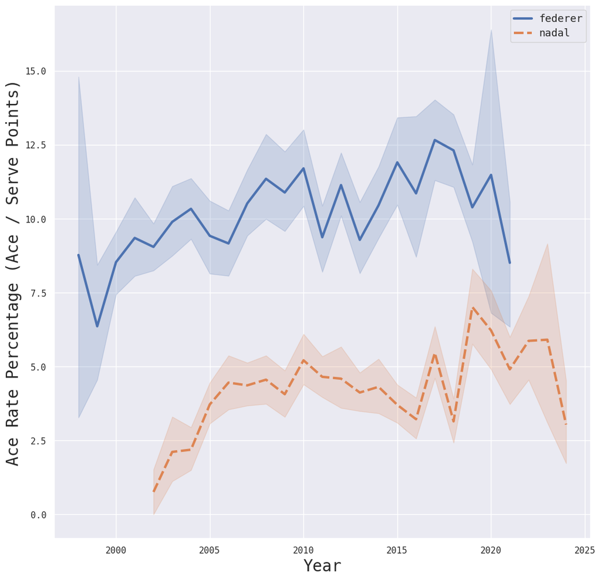

```python
plot_data(all_aces_plot, xlabel="Year", ylabel="Ace Rate Percentage (Ace / Serve Points)", invert=False)
```

Let's get the ace rates of some more selected top players, as well as that of John Isner, known as an all-time acing great, and Giovanni Mpetshi Perricard, known as the current pro circuit's acing great.

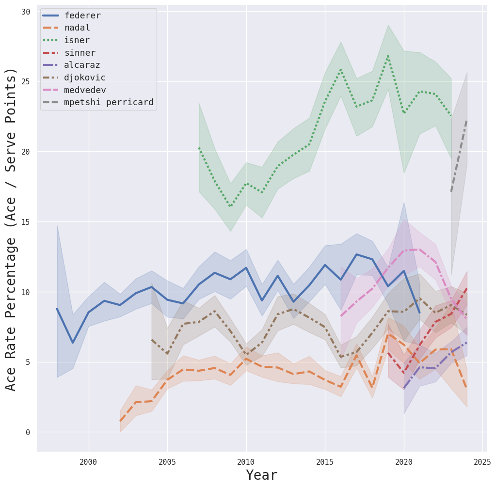

```python
add_players = [("John", "Isner"), ("Jannik", "Sinner"), ("Carlos", "Alcaraz"), ("Novak", "Djokovic"), ("Daniil", "Medvedev"), ("Giovanni", "Mpetshi Perricard")]

for player in add_players:
    all_aces, all_aces_plot = add_ace_rate(player[0], player[1], full_matches, all_aces)

plot_data(all_aces_plot, xlabel="Year", ylabel="Ace Rate Percentage (Ace / Serve Points)", invert=False)
```

And again, but without confidence interval highlighting so it's a little less dense.

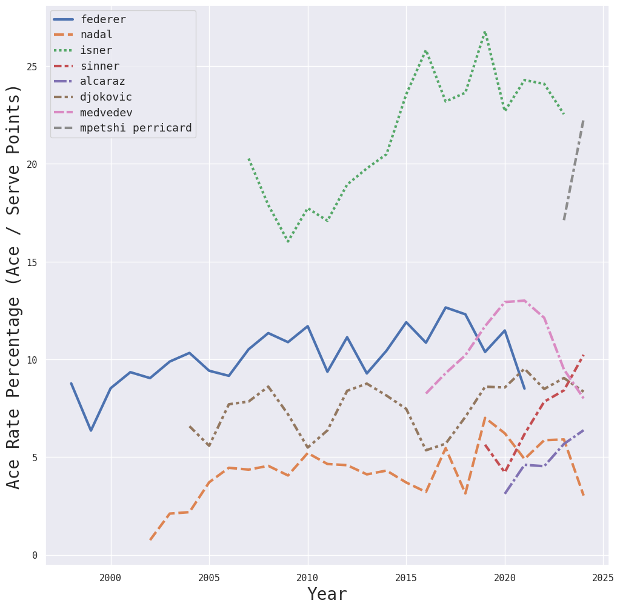

```python
plot_data(all_aces_plot, xlabel="Year", ylabel="Ace Rate Percentage (Ace / Serve Points)", invert=False, confidence_interval=False)
```

We see that, among top players, Federer, Medvedev, and recently, Sinner, have the greatest acing ability, while someone like Nadal achieved his greatness perhaps through other means. We see that Djokovic is generally in the middle of the pack. I'm personally surprised that one of the hardest hitters on tour, Carlos Alcaraz, has a relatively tame acing rate (for a #1 or former #1 player). We get insight here not just into how a player's acing/serving strategy has changed throughout their career, but also insight into how they play the game in general. Someone like Mpetshi Perricard perhaps focuses more on shortening points by trying to blast serves past his opponents, while someone like Nadal may look to grind his opponents down in longer points with less of an emphasis on serving.

That being said, notice the tour's upper echelon of serving. I knew going into this project that Isner and Mpetshi Perricard were heavy servers, but they are truly in another league compared to even former #1 players. At a point in his career, Isner's serve rate was a completely ridiculous one in four; statistically, he would have over a 25% chance of hitting an ace every time he served. This hits harder if you've ever yourself attempted to hit a tennis serve.

Future work from this point could include adjacent statistics like double fault rate or first-serve rate to get an even fuller picture of each players' serve and serving strategy, and from there an analysis of other tennis shots (forehand, backhand, etc.), though just the ace rate alone already gives great insight into my motivating question.

## Impact

Visualizing and understanding a player's ace rate, and for that matter, every aspect of their performance and play, I think is crucial in beating the razor-thin margins of error in the pro tour I mentioned earlier. A pro tennis player must be aware of precisely how their play is shifting, and these visualizations provide that. Looking at the data tells a player whether they are meeting their intended playstyle and playing strategy, and how other players are shifting their playstyles and strategies. I wonder if Medvedev is aware of the dip in his acing rate over the past few years; if not, this data would help.

### Reference acknowledgements:

Pandas/seaborn documentation, class materials/demos/labs, and Google Search AI for help with pandas and seaborn functionalities, syntax, and debugging.

#### Additionally:

https://stackoverflow.com/questions/10715519/conditionally-fill-column-values-based-on-another-columns-value-in-pandas https://stackoverflow.com/questions/51787247/pandas-update-column-values-from-another-column-if-criteria https://www.reddit.com/r/learnpython/comments/q9e1rr/pandas_df_lambda_got_an_unexpected_keyword/ https://stackoverflow.com/questions/21800169/python-pandas-get-index-of-rows-where-column-matches-certain-value https://stackoverflow.com/questions/44880444/how-to-increase-the-font-size-of-the-legend-in-seaborn https://stackoverflow.com/questions/62667158/how-do-i-increase-the-line-thickness-for-sns-lineplot https://stackoverflow.com/questions/53747298/how-to-format-axis-tick-labels-from-number-to-thousands-or-millions-125-436-to